# Article_Categorization (1)

```python
from google.colab import drive
drive.mount('/content/drive')
```

```python
# Installing the libraries with the specified version.
# !pip install tensorflow==2.15.0
# !pip install scikit-learn==1.2.2
# !pip install seaborn==0.13.1
# !pip install matplotlib==3.7.1
# !pip install numpy==1.25.2
# !pip install pandas==1.5.3
# !pip install torch==2.1.0
# !pip install sentence-transformers==2.5.1 transformers==4.38.2 bitsandbytes==0.43.0 accelerate==0.27.2 sentencepiece==0.2.0 -q --user
```

[output not shown]

```python
!pip install -U sentence-transformers
```

```
  Using cached sentence_transformers-2.7.0-py3-none-any.whl (171 kB)
  Attempting uninstall: sentence-transformers
    Found existing installation: sentence-transformers 2.5.1
    Uninstalling sentence-transformers-2.5.1:
      Successfully uninstalled sentence-transformers-2.5.1
```

```python
import pandas as pd
import numpy as np
import matplotlib.pyplot as plt
import seaborn as sns
pd.set_option('max_colwidth', None)

import torch
from sentence_transformers import SentenceTransformer
from transformers import T5Tokenizer, T5ForConditionalGeneration, pipeline
# To build a Random Forest model
from sklearn.ensemble import RandomForestClassifier

# to split the data
from sklearn.model_selection import train_test_split
# to compute performance metrics
from sklearn.metrics import confusion_matrix, classification_report, accuracy_score,make_scorer,recall_score,precision_score,f1_score
from sklearn.model_selection import GridSearchCV

# to ignore unnecessary warnings
import warnings
warnings.filterwarnings("ignore")
```

### Loading DataSet

```python
# Loading csv file
path = "/content/drive/MyDrive/article_data.csv"
data = pd.read_csv(path)
```

```python
# displaying data sample
data.head(5)
```

|  | Article | Category |
| --- | --- | --- |
| 0 | Sudan Govt rejects call to separate religion, state Sudanese rebel leaders #39; demand that Islam be kept out of government in the war-torn region of Darfur, has been rejected by government negotiator… | 0 |
| 1 | Hassan: #39;Abhorrent act #39; says Blair Western political leaders have united to condemn the kidnappers of charity worker Margaret Hassan after a video surfaced apparently showing a militant firing … | 0 |
| 2 | Sharon Says Gaza Evacuation Set for 2005 (AP) AP - Israel's evacuation of the Gaza Strip will begin next summer and will take about 12 weeks, Prime Minister Ariel Sharon said Wednesday, reversing an e… | 0 |
| 3 | Prince Charles chastised for quot;old fashioned quot; views A minister has launched a scathing attack on heir to the throne Prince Charles, accusing him of being quot;very old fashioned quot; and out … | 0 |
| 4 | U.S. Says N.Korea Blast Probably Not Nuclear SEOUL (Reuters) - A huge explosion rocked North Korea last week but U.S. and South Korean officials said on Sunday it was unlikely to have been a nuclear w… | 0 |

```python
# checking the shape of dataset
data.shape
```

```
(4000, 2)
```

The dataset has 4000 rows and 2 columns

```python
## Complete the code to check the value counts in Category column
data["Category"].value_counts()
```

```
0    1000
1    1000
2    1000
3    1000
Name: Category, dtype: int64
```

The dataset contains 1000 sets of each category i.e., category 0, 1,2,3

```python
# Checking for missing value
data.isnull().sum()
```

```
Article     0
Category    0
dtype: int64
```

There are no missing values in the dataset

### Exploratory Data Analysis (EDA)

```python
# function to create labeled barplots

def labeled_barplot(data, feature, perc=False, n=None):
    """
    Barplot with percentage at the top

    data: dataframe
    feature: dataframe column
    perc: whether to display percentages instead of count (default is False)
    n: displays the top n category levels (default is None, i.e., display all levels)
    """

    total = len(data[feature])  # length of the column
    count = data[feature].nunique()
    if n is None:
        plt.figure(figsize=(count + 1, 5))
    else:
        plt.figure(figsize=(n + 1, 5))

    plt.xticks(rotation=90, fontsize=15)
    ax = sns.countplot(
        data=data,
        x=feature,
        palette="Paired",
        order=data[feature].value_counts().index[:n].sort_values(),
    )

    for p in ax.patches:
        if perc == True:
            label = "{:.1f}%".format(
                100 * p.get_height() / total
            )  # percentage of each class of the category
        else:
            label = p.get_height()  # count of each level of the category

        x = p.get_x() + p.get_width() / 2  # width of the plot
        y = p.get_height()  # height of the plot

        ax.annotate(
            label,
            (x, y),
            ha="center",
            va="center",
            size=12,
            xytext=(0, 5),
            textcoords="offset points",
        )  # annotate the percentage

    plt.show()  # show the plot
```

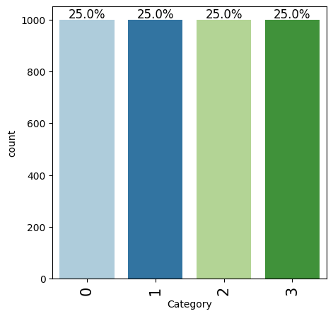

```python
# Distribution of category
labeled_barplot(data, "Category", perc=True)
```

All categories has same distribution

### Model Building - Sentence Transformer + ML

#### Defining the SentenceTransformer Model

```python
## Defining the model.
model = SentenceTransformer('sentence-transformers/all-MiniLM-L6-v2')
```

```python
def confusion_matrix_sklearn(model, predictors, target):
    """
    To plot the confusion_matrix with percentages

    model: classifier
    predictors: independent variables
    target: dependent variable
    """
    y_pred = model.predict(predictors)
    cm = confusion_matrix(target, y_pred)
    labels = np.asarray(
        [
            ["{0:0.0f}".format(item) + "\n{0:.2%}".format(item / cm.flatten().sum())]
            for item in cm.flatten()
        ]
    ).reshape(cm.shape[0], cm.shape[1])

    plt.figure(figsize=(6, 4))
    sns.heatmap(cm, annot=labels, fmt="")
    plt.ylabel("True label")
    plt.xlabel("Predicted label")
```

### Encoding the data

```python
# setting the compute device
device = "cuda" if torch.cuda.is_available() else "cpu"

## Encoding the dataset.
embedding_matrix = model.encode(data["Article"],show_progress_bar=True,device=device)
```

### Train-Test Split

```python
# Split the data
X = embedding_matrix
y = data["Category"]
```

```python
# Initial split into training (80%) and testing (20%)
X_train, X_temp, y_train, y_temp = train_test_split(X, y, test_size=0.20, random_state=42)

# Further split the temporary set into validation (10%) and test (10%) sets
X_valid, X_test, y_valid, y_test = train_test_split(X_temp, y_temp, test_size=0.50, random_state=42)
```

```python
print("Shape of the set of input variables for training:", X_train.shape)    # Complete the code to get the shape of training input data
print("Shape of the set of input variables for validation:", X_valid.shape)    # Complete the code to get the shape of validation input data
print("Shape of the set of input variables for testing:", X_test.shape)
```

```
Shape of the set of input variables for training: (3200, 384)
Shape of the set of input variables for validation: (400, 384)
Shape of the set of input variables for testing: (400, 384)
```

```python
print("Shape of the set of output variables for training:", y_train.shape)    # Complete the code to get the shape of training output data
print("Shape of the set of output variables for validation:", y_valid.shape)    # Complete the code to get the shape of validation output data
print("Shape of the set of output variables for testing:", y_test.shape)     # Complete the code to get the shape of testing output data
```

```
Shape of the set of output variables for training: (3200,)
Shape of the set of output variables for validation: (400,)
Shape of the set of output variables for testing: (400,)
```

### Random Forest Model (base)

```python
# defining a function to compute different metrics to check performance of a classification model built using sklearn

def model_performance_classification_sklearn(model, predictors, target):
    """
    Function to compute different metrics to check classification model performance

    model: classifier
    predictors: independent variables
    target: dependent variable
    """

    # predicting using the independent variables
    pred = model.predict(predictors)

    acc = accuracy_score(target, pred)  # to compute Accuracy
    recall = recall_score(target, pred,average="weighted")  # to compute Recall
    precision = precision_score(target, pred,average="weighted")  # to compute Precision
    f1 = f1_score(target, pred,average="weighted")  # to compute F1-score

    # creating a dataframe of metrics
    df_perf = pd.DataFrame(
        {"Accuracy": acc, "Recall": recall, "Precision": precision, "F1": f1,},
        index=[0],
    )

    return df_perf
```

```python
## Building the model
rf = RandomForestClassifier(random_state = 42)

## Compete the code to fit the model on X_train and y_train
rf.fit(X_train, y_train)
```

```
RandomForestClassifier(random_state=42)
```

#### Confusion Matrix

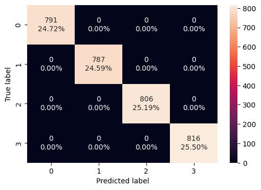

```python
## To get the confusion matrix on X_train and y_train
confusion_matrix_sklearn(rf, X_train, y_train)
```

Class 0: 791 instances were correctly predicted, making up 24.72% of the total predictions.

Class 1: 787 instances were correctly predicted, making up 24.59% of the total predictions.

Class 2: 806 instances were correctly predicted, making up 25.19% of the total predictions.

Class 3: 816 instances were correctly predicted, making up 25.50% of the total predictions.

The matrix suggests that the classes are balanced, as the percentages are nearly equal across all classes, and the model performs uniformly well across these classes.

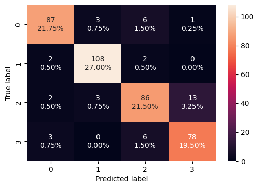

```python
## Write the code to get the confusion matrix for X_valid and y_valid
confusion_matrix_sklearn(rf, X_valid, y_valid)
```

Class 0: 87 instances were correctly predicted as class 0, which is 21.75% of total predictions. However, 3 instances were incorrectly predicted as class 1, 6 as class 2, and 1 as class 3.

Overall, while the model demonstrates some level of accuracy, misclassifications are present across all classes, with the highest number of errors occurring when instances of class 2 are predicted as class 3 and vice versa.

```python
# Predicting on train data
y_pred_train = rf.predict(X_train)

# Predicting on validation data
y_pred_valid = rf.predict(X_valid)
```

Classification report

```python
## Classification report for train data
print(classification_report(y_train, y_pred_train))
```

```
              precision    recall  f1-score   support

           0       1.00      1.00      1.00       791
           1       1.00      1.00      1.00       787
           2       1.00      1.00      1.00       806
           3       1.00      1.00      1.00       816

    accuracy                           1.00      3200
   macro avg       1.00      1.00      1.00      3200
weighted avg       1.00      1.00      1.00      3200
```

```python
## Write the code to get the classification report for validation data
print(classification_report(y_valid, y_pred_valid))
```

```
              precision    recall  f1-score   support

           0       0.93      0.90      0.91        97
           1       0.95      0.96      0.96       112
           2       0.86      0.83      0.84       104
           3       0.85      0.90      0.87        87

    accuracy                           0.90       400
   macro avg       0.90      0.90      0.90       400
weighted avg       0.90      0.90      0.90       400
```

```python
## Storing the metrics
rf_train_perf = model_performance_classification_sklearn(
    rf, X_train, y_train
)
```

```python
## Storing the metrics
rf_valid_perf = model_performance_classification_sklearn(
    rf, X_valid, y_valid
)
```

### Random Forest (with class_weights)

```python
## Building the model
rf_balanced = RandomForestClassifier(class_weight="balanced", random_state=42)

## Complete the code to fit the model on X_train and y_train
rf_balanced.fit(X_train, y_train)
```

```
RandomForestClassifier(class_weight='balanced', random_state=42)
```

Confusion Matrix

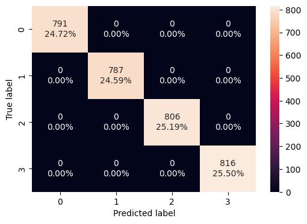

```python
## To get the confusion matrix on X_train and y_train
confusion_matrix_sklearn(rf_balanced, X_train, y_train)
```

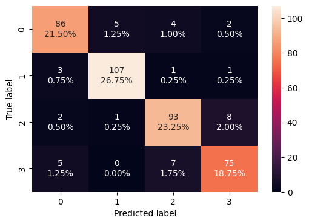

```python
## Write the code to get the confusion matrix for X_valid and y_valid
confusion_matrix_sklearn(rf_balanced, X_valid, y_valid)
```

There are few mis-classifications on all the categories.

```python
## Predicting on train data
y_pred_train = rf_balanced.predict(X_train)

## Complete the code to predict the model on X_valid
y_pred_valid = rf_balanced.predict(X_valid)
```

Classification report

```python
## Classification report for train data
print(classification_report(y_train, y_pred_train))
```

```
              precision    recall  f1-score   support

           0       1.00      1.00      1.00       791
           1       1.00      1.00      1.00       787
           2       1.00      1.00      1.00       806
           3       1.00      1.00      1.00       816

    accuracy                           1.00      3200
   macro avg       1.00      1.00      1.00      3200
weighted avg       1.00      1.00      1.00      3200
```

```python
## Write the code to get the classification report for validation data
print(classification_report(y_valid, y_pred_valid))
```

```
              precision    recall  f1-score   support

           0       0.90      0.89      0.89        97
           1       0.95      0.96      0.95       112
           2       0.89      0.89      0.89       104
           3       0.87      0.86      0.87        87

    accuracy                           0.90       400
   macro avg       0.90      0.90      0.90       400
weighted avg       0.90      0.90      0.90       400
```

Overall, the classification report indicates that the model performs reasonably well on the validation data, with high precision, recall, and F1-scores for most classes, and an accuracy of 0.90.

```python
## Storing the metrics
rf_bal_train_perf = model_performance_classification_sklearn(
    rf_balanced, X_train, y_train
)
```

```python
## Complete the code to store the metrics of validation data
rf_bal_valid_perf = model_performance_classification_sklearn(
    rf_balanced, X_valid, y_valid
)
```

Random Forest (with hyperparamter tuning)

```python
# ## Building the model
# rf_tuned = RandomForestClassifier(class_weight="balanced", random_state=42)

# ## Defining the hyperparameter grid for tuning
# parameters = {
#     "max_depth": list(np.arange(4, 10, 3)),
#     "max_features": ["sqrt", 0.5, 0.7],
#     "min_samples_split": [5, 6],
#     "n_estimators": np.arange(30, 110, 15),
# }

# ## Defining the type of scoring used to compare parameter combinations
# ## We need to specify the mechanism of averaging as we have more than 2 target classes
# scorer = make_scorer(recall_score, average='weighted')

# ## Running the grid search
# grid_obj = GridSearchCV(rf_tuned, parameters, scoring=scorer, cv=3, n_jobs=-1)

# ## Complete the code to fit the model on X_train and y_train
# grid_obj = grid_obj.fit(X_train, y_train)
```

*The Random Forest (with hyperparamter tuning) is taking a lot of time to execute. The run time has exceeded for more than 20 mins now, Hence I'm commenting out the hypertuning section and further selections will not include RF with hyperparameterized tuning*